# Status loss and participation

## Emotions among users with loss: +5 pp

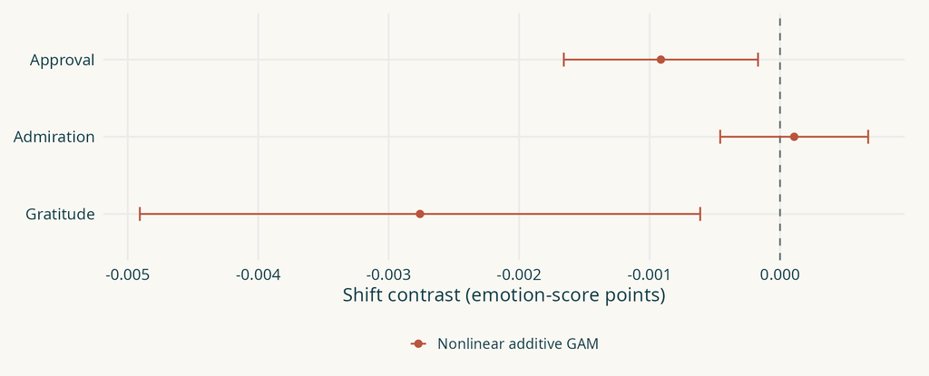

Main GAM; prior characteristics in original units. Average: 8,663 supported users with positive observed loss. Training: 15,982. 200 user draws; 95% pointwise intervals; fixed support and GAM basis/penalties.

Main GAM; prior characteristics in original units. Average: 8,663 supported users with positive observed loss. Training: 15,982. 200 user draws; 95% pointwise intervals; fixed support and GAM basis/penalties.

Approval and gratitude have negative GAM intervals; admiration remains uncertain.

## Emotions among users with loss: +10 pp

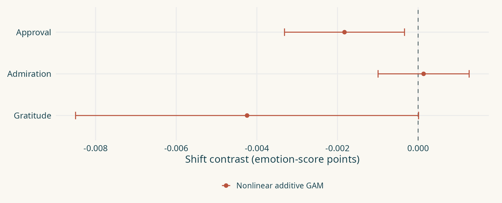

Main GAM; prior characteristics in original units. Average: 6,035 supported users with positive observed loss. Training: 15,982. 200 user draws; 95% pointwise intervals; fixed support and GAM basis/penalties.

Main GAM; prior characteristics in original units. Average: 6,035 supported users with positive observed loss. Training: 15,982. 200 user draws; 95% pointwise intervals; fixed support and GAM basis/penalties.

Approval has a negative GAM interval; admiration and gratitude remain uncertain.

## Emotions among users with loss: +20 pp

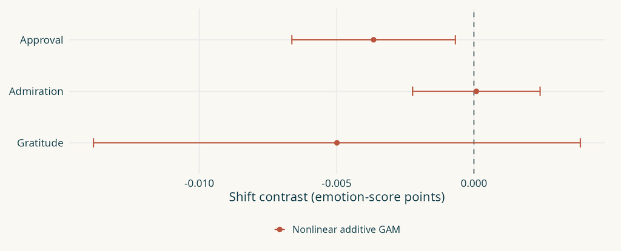

Main GAM; prior characteristics in original units. Average: 2,370 supported users with positive observed loss. Training: 15,982. 200 user draws; 95% pointwise intervals; fixed support and GAM basis/penalties.

Main GAM; prior characteristics in original units. Average: 2,370 supported users with positive observed loss. Training: 15,982. 200 user draws; 95% pointwise intervals; fixed support and GAM basis/penalties.

Approval has a negative GAM interval; admiration and gratitude remain uncertain.

## Emotions among users with loss: +25 pp

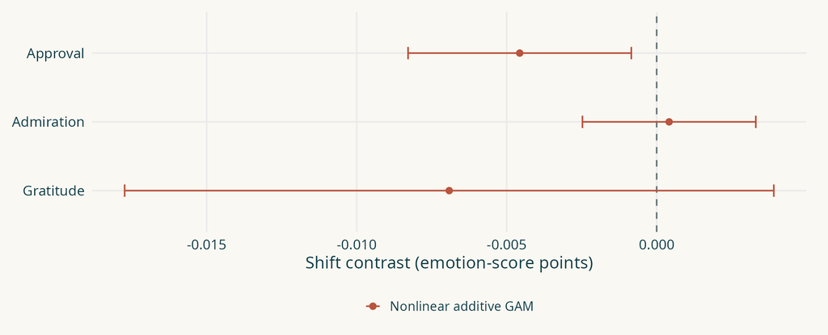

Main GAM; prior characteristics in original units. Average: 1,322 supported users with positive observed loss. Training: 15,982. 200 user draws; 95% pointwise intervals; fixed support and GAM basis/penalties.

Main GAM; prior characteristics in original units. Average: 1,322 supported users with positive observed loss. Training: 15,982. 200 user draws; 95% pointwise intervals; fixed support and GAM basis/penalties.

Approval has a negative GAM interval; admiration and gratitude remain uncertain.

## 4 · Why study interaction context?

If gratitude falls after reputation loss, do users **thank less for the same help**, or encounter **fewer situations that invite thanks**?

1. **Locate comments:** own question, own answer, or others’ threads.
2. **Describe gratitude:** where thanking is more common.
3. **Separate changes:** expression within contexts versus the mix of contexts.
4. **Compare within context:** current thanking estimates remain imprecise.
5. **Next step:** all received contributions, including no reply — whether users respond, thank, and how.

**Illustration:** 10 answers received → 5 thanked; later, 2 → 1. Fewer thanks, but the **same thanking rate: 50%**.

The current analysis starts from observed comments. The complete received-contribution comparison is a proposed next step; the example is illustrative.

## Context starts with the commenter’s role

| Context in the emotion plots | What the same user does |
| --- | --- |
| Answers to own question | I asked; I comment on an answer to my question. |
| Own question | I asked; I comment under my question. |
| Own answer | Someone else asked; I answered; I comment under my answer. |
| Others’ threads | Other comments in threads where I did not ask the question. |

“Own” refers to the person writing the comment. Context identifies the question author and the commented post. It does not identify the trigger or verify that an answer to one’s question came from someone else.

## The detailed classification separates seven locations

| ID | Who asked the question? | Where does the focal user comment? |
| --- | --- | --- |
| 1 | The focal user | On an answer to their question |
| 2 | The focal user | On their question |
| 3 | Someone else | On the focal user’s own answer |
| 4 | Someone else; user also has an answer | On another answer |
| 5 | Someone else; user also has an answer | On the question |
| 6 | Someone else; no answer by user recorded | On an answer |
| 7 | Someone else; no answer by user recorded | On the question |

The “where users thank” analysis uses these seven categories. Categories 4–7 form “Others’ threads” in the four-category emotion plots. Having an answer is checked in the full recorded file, not necessarily before the comment.

## Where thanks occur and how often users thank differ

| Quantity | Numerator / denominator | Question answered |
| --- | --- | --- |
| Share of thanks by context | Thanks in context / all thanks in that group | Where do users thank? |
| Thanks rate within context | Thanks in context / all comments in that context | How often do comments say thanks there? |
| Gratitude score | Mean GoEmotions score among comments in context | What gratitude does the text express? |

Current rates describe observed comments. A rate per opportunity would start from every contribution received, including those with no subsequent comment.

Explicit thanks = thank / thanks / thx / ty. The gratitude score is a separate model-based measure. Neither measures unexpressed gratitude.

## Where controls thank: their own questions and their own answers

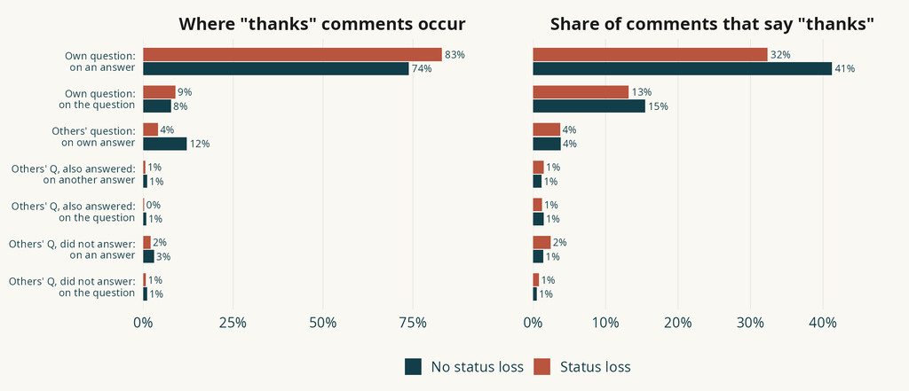

Pre-reform comments of eligible users. Left: share of each group’s “thanks” comments in each context. Right: share of comments in each context that say thanks (thank, thanks, thx, ty).

Pre-reform comments of eligible users. Left: share of each group’s “thanks” comments in each context. Right: share of comments in each context that say thanks (thank, thanks, thx, ty).

**12 % of controls’ thanks occur on their own answers.** Both groups thank in about 4 % of comments there; the preceding contribution still needs to be identified.

## Focal emotions differ across interaction contexts

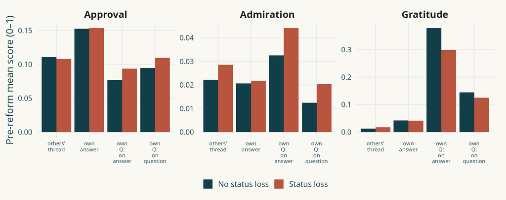

Compare approval, admiration and gratitude within the same context. These are mean scores among observed comments, not treatment effects.

## Thanking over time in the two main contexts

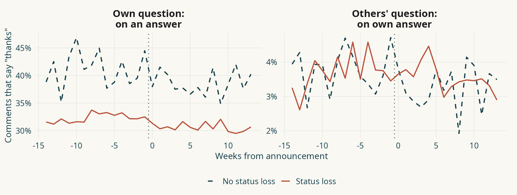

Weekly share of comments that say thanks, eligible users, in the two contexts where controls thank most. Every comment weighs one. Week 0 = first week after announcement.

Weekly share of comments that say thanks, eligible users, in the two contexts where controls thank most. Every comment weighs one. Week 0 = first week after announcement.

Rates describe observed comments, not all received opportunities. Compare each context separately; changing participation can alter the lines.

## Context composition contributes to gratitude changes

| Pre → post gratitude change | Total | Within context | Composition |
| --- | --- | --- | --- |
| Status loss | −0.021 | −0.007 | −0.015 |
| No status loss | −0.008 | −0.004 | −0.004 |

Answers to own question: treated 37.6% → 32.8%; controls 15.7% → 15.0%.

Composition accounts for about 69% of the treated decline and 47% of the control decline. Both groups now decline in the full eligible corpus.

Descriptive decomposition: within = Σ share_post × Δgratitude; composition = Σ Δshare × gratitude_pre. It is not a treatment-effect decomposition.

## A thread location is not yet a comparable event

### Current evidence

Where the user comments and the first comment observed on a post.

### Next comparison

A contribution received → a chance to respond → the subsequent response.

Start an event when the contribution arrives. Count **response**, **thanks within a fixed window**, and **tone among responders** separately.

## Observed event: first comment on an answer to own question

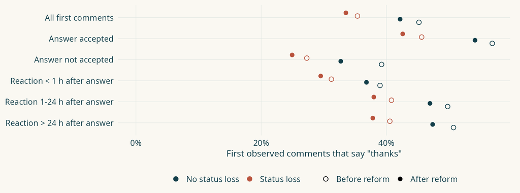

First comment observed in the text window on each answer to own question (144,319); the selection rule does not exclude self-answers. Only commenters enter. Acceptance and timing coverage: 71.7 %; acceptance is a recorded status, not necessarily status at reaction. Open: pre; filled: post.

Text/context uses its own saved matching design; these models have not been re-estimated with the activity matches. First comment observed in the text window on each answer to own question (144,319); the selection rule does not exclude self-answers. Only commenters enter. Acceptance and timing coverage: 71.7 %; acceptance is a recorded status, not necessarily status at reaction. Open: pre; filled: post.

**Among observed first comments, controls thank more before and after.** Acceptance and response delay describe selected reactions; neither defines a pre-treatment control.

## Context and observed-comment comparison: code

```r
# cm joins comment scores, thread owners and answer authors.
# answered is joined by (user_id, thread), using the full record.
cm[, `:=`(own_q = !is.na(q_user) & q_user == user_id,
           on_question = post_id == thread)]  # flags used to define seven contexts
cm[, thanks := as.integer(grepl("\\b(thank|thanks|thx|ty)\\b", body,
                                ignore.case = TRUE, perl = TRUE))]
first_reaction = cm[context == "1 Own question: on an answer"][order(creation_date)][
  , .SD[1], by = .(user_id, post_id)]  # first observed comment in the text window
units = copy(first_reaction)           # example event; context models select from cm

d = units[, .(y = mean(thanks)),
          by = .(user_id, treated, period = fifelse(t_week < 0, 1L, 2L))]
d = merge(d, designs[design == "PSM/Mahalanobis", .(user_id, weight)], by = "user_id")
d[, g := 2L * treated]                 # treated from period 2; controls remain 0
fit = att_gt(yname = "y", tname = "period", idname = "user_id", gname = "g",
  weightsname = "weight", data = d, est_method = "dr", allow_unbalanced_panel = TRUE)
average = aggte(fit, type = "simple")
```

**Input.** `cm`: comments joined to thread authorship and text scores; saved PSM/CEM user weights.

**Objects.** `first_reaction`: first observed comment per answer in own-question threads; `d`: mean thanks by user-period.

**Result.** `context_events_att.csv`: context/event contrasts. No-reply opportunities are absent; the earlier text/context match is retained.

Code excerpt: `32_context_events.R`. Objects are prepared by the full script.

Context/event restriction + PSM/CEM user weights; **no additional covariates**. All available user-periods enter; incomplete panels use repeated-cross-section estimation.

Text/context uses its own saved matching design; these models have not been re-estimated with the activity matches.

## Within-context estimates remain uncertain

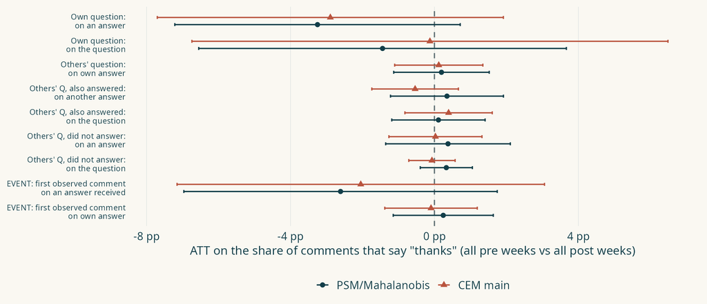

DiD on user-period shares of observed comments saying thanks; current PSM/CEM weights, all available user-periods. Incomplete panels use repeated-cross-section estimation. Bars: 95% intervals; the event covers commenters only.

Text/context uses its own saved matching design; these models have not been re-estimated with the activity matches. DiD on user-period shares of observed comments saying thanks; current PSM/CEM weights, all available user-periods. Incomplete panels use repeated-cross-section estimation. Bars: 95% intervals; the event covers commenters only.

**All estimated explicit-thanks intervals include zero.** In the first-comment-on-answer-received model, 247 PSM / 637 CEM controls appear in both periods; models use all available user-periods.

## Within-context effects on the three focal emotions

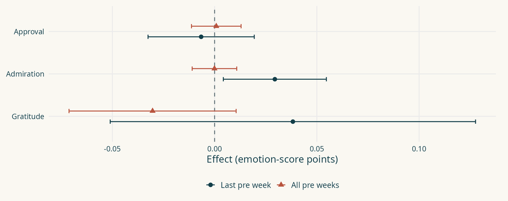

PSM ATT on user-week mean scores within comments on answers to one’s own question, eligible analysis sample (5,525 treated). Circles: last pre week; triangles: all pre weeks. Bars: 95% intervals.

Text/context uses its own saved matching design; these models have not been re-estimated with the activity matches. PSM ATT on user-week mean scores within comments on answers to one’s own question, eligible analysis sample (5,525 treated). Circles: last pre week; triangles: all pre weeks. Bars: 95% intervals.

Approval, admiration and gratitude are shown in original score units; compare estimates and intervals.

## Within-context event study: no clear sustained shift

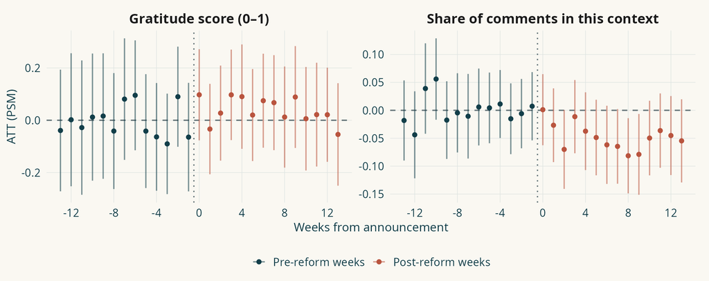

did dynamic ATT, PSM users with comments on answers to their own question (5,525 treated), eligible analysis sample. Bars: simultaneous 95% bands. Week 0 = first week after announcement.

Text/context uses its own saved matching design; these models have not been re-estimated with the activity matches. did dynamic ATT, PSM users with comments on answers to their own question (5,525 treated), eligible analysis sample. Bars: simultaneous 95% bands. Week 0 = first week after announcement.

**Gratitude remains imprecise within this context.** Observed users can change across weeks; these are selected comments, not all opportunities to respond.

## Candidate events shared by both groups

| Contribution received | User’s role | Reaction to measure |
| --- | --- | --- |
| Correction + proposed fix | Author of an answer | Acknowledges, thanks, revises or disagrees |
| Example, reference or alternative | Author of an answer | Recognizes or incorporates the contribution |
| Request for clarification | Author of a question or answer | Clarifies, cooperates or expresses annoyance |
| Answer to a question | Question author | Thanks, asks follow-up or stays silent |

Prioritize feedback on **one’s own answer**. First review control threads, then identify every comparable event in both groups, including those without thanks.

## Match the preceding contribution, then compare reactions

1. Identify the recipient, prior contribution, timing and intended addressee.
2. Compare the same role and contribution type, topic, prior relationship and interaction stage.
3. Check event counts, users and overlap in both groups before and after the reform.
4. Use a fixed follow-up window; report response rates and written thanks per opportunity.

Estimate participation and reaction separately. Conditioning on a post-reform context can select a different population; acceptance and response delay are not baseline controls.

## 5 · Conclusions and next steps

What the evidence supports, and what comes next.

## Action pilot: latest run ended with eight failed batches

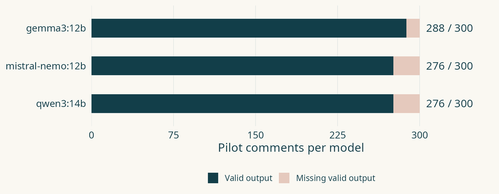

Latest saved run: October 16, 2026; checked October 20. Gemma: 288/300; Mistral and Qwen: 276/300 each. All 114 batches were attempted: 106 valid, 8 failed. Coverage measures output validity, not classification accuracy.

Latest saved run: October 16, 2026; checked October 20. Gemma: 288/300; Mistral and Qwen: 276/300 each. All 114 batches were attempted: 106 valid, 8 failed. Coverage measures output validity, not classification accuracy.

**840/900 valid model–comment outputs; 240 comments covered by all three models.** Review failed batches and consolidate the action codebook before human validation.

## Next steps: validate actions, then estimate changes

### 1 · Review

Review 8 failed batches and 60 missing outputs; use 240 shared comments for comparison.

### 2 · Define

Consolidate action labels, examples and rules for ambiguity.

### 3 · Validate

Freeze the codebook; evaluate against independent human labels on reserved users.

### 4 · Estimate

Build user-level action counts and shares; compare pre/post changes.

Keep development and evaluation users separate. **Coverage is not accuracy; proposed action labels are not yet validated outcomes.**

## What the completed analyses show

### Activity comparisons

Unmatched comments estimates are negative under all three weekly alternatives. Both matching designs remain main; broad-pre comments contrasts are negative in both.

### Binary text

Text-specific matching: approval is positive under both baselines; admiration and gratitude depend on the baseline.

### Interaction

Explicit-thanks intervals include zero. A complete opportunity-based design remains to be built.

**Current continuous treatment, +15 pp:** among users with positive loss, the main GAM shows lower answers, accepted answers and approval. Comments, admiration and gratitude remain uncertain. The linear comparison and broader target are in the appendix.

## Appendix: secondary checks and additional results

First: linear/GAM comparisons and the previous transformed-covariate focal results. Then: the preserved broader continuous-loss target, including zero-loss users. Then: conditional weekly adjustments, earlier restricted-training dose fits, TWFE and complete emotion results. Each version retains its own population and interpretation.

## Raw covariates: compare both activity models

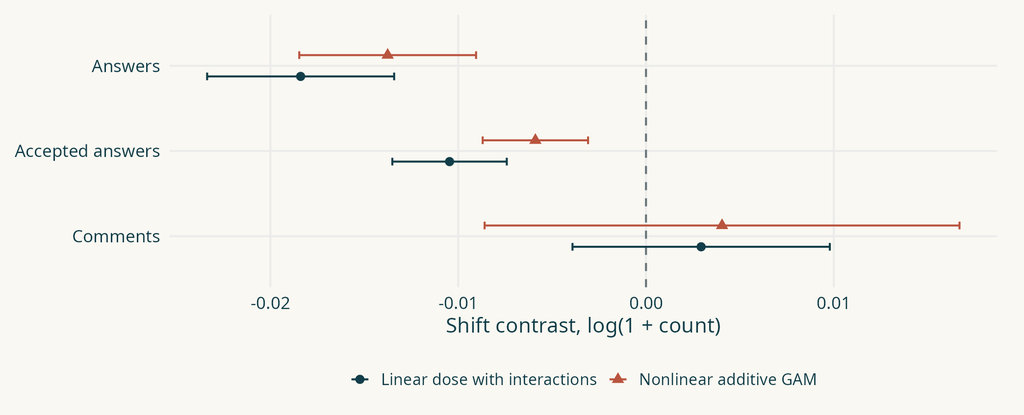

Raw covariates, +15 pp; same positive-loss target; linear interactions and additive GAM.

+15 pp; same positive-loss target and full eligible training. Raw prior-history covariates; 200 user draws; 95% pointwise intervals. Models differ in both interactions and curvature.

Answers and accepted answers have negative intervals in both models. Both comment intervals include zero.

## Raw covariates: compare both emotion models

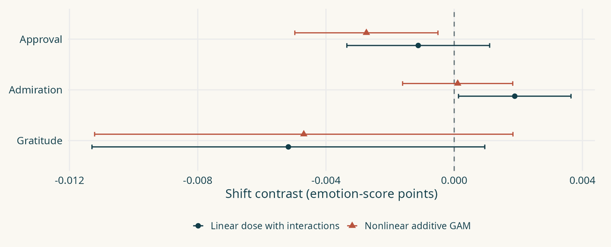

Raw covariates, +15 pp; same positive-loss target; linear interactions and additive GAM.

+15 pp; same positive-loss target and full eligible training. Raw prior-history covariates; 200 user draws; 95% pointwise intervals. Models differ in both interactions and curvature.

Approval is negative only in GAM; admiration is positive only in the linear model. Gratitude intervals include zero in both.

## Previous covariate scales: activity, +15 pp

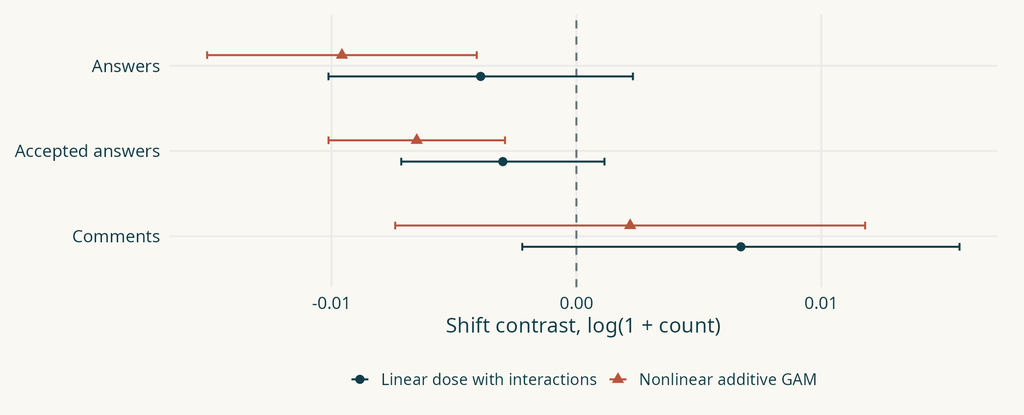

Training: 25,218 eligible valid-outcome users. Average: 6,153 users with observed loss >0 and support for +15 pp. Two models; 200 user draws; 95% pointwise intervals; fixed support and GAM basis/penalties.

**Previous specification: log prior counts and asinh prior reputation. Same positive-loss target.** Training: 25,218 eligible valid-outcome users. Average: 6,153 users with observed loss >0 and support for +15 pp. Two models; 200 user draws; 95% pointwise intervals; fixed support and GAM basis/penalties.

Answers and accepted answers have negative intervals in the GAM; the linear intervals include zero. Both comment intervals include zero.

## Previous covariate scales: emotions, +15 pp

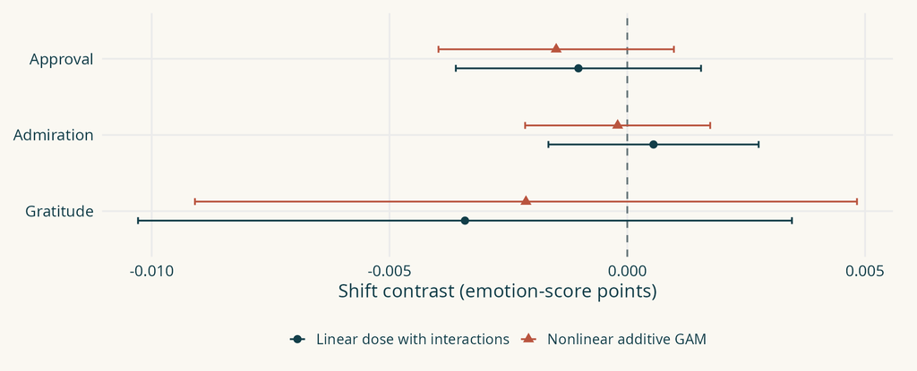

Training: 15,982 eligible valid-outcome users. Average: 3,892 users with observed loss >0 and support for +15 pp. Two models; 200 user draws; 95% pointwise intervals; fixed support and GAM basis/penalties.

**Previous specification: log prior counts and asinh prior reputation. Same positive-loss target.** Training: 15,982 eligible valid-outcome users. Average: 3,892 users with observed loss >0 and support for +15 pp. Two models; 200 user draws; 95% pointwise intervals; fixed support and GAM basis/penalties.

Approval, admiration and gratitude: all intervals include zero in both models.

## Appendix: the broader target includes zero loss

| Increment | Activity: positive loss | Activity: zero loss | Total activity target | Text target |
| --- | --- | --- | --- | --- |
| +5 pp | 12,478 | 3,344 | 15,822 | 10,011 |
| +10 pp | 9,117 | 3,110 | 12,227 | 7,191 |
| +15 pp | 6,153 | 2,648 | 8,801 | 4,809 |
| +20 pp | 3,909 | 1,861 | 5,770 | 2,817 |
| +25 pp | 2,323 | 432 | 2,755 | 1,519 |

**Different question:** the average includes users with no measured loss. For them, +15 pp compares predictions at 0% and 15% loss. These preserved results also use transformed prior covariates; they differ from the main analysis in both target and covariate scales.

Earlier averages: script 38, run f041ac774eb02016. Earlier weekly activity: script 40, run 08d9546dbb546948. Full eligible training; increment-specific support; 200 user draws. No old result was overwritten.

## Appendix: all supported users — activity, +5 pp

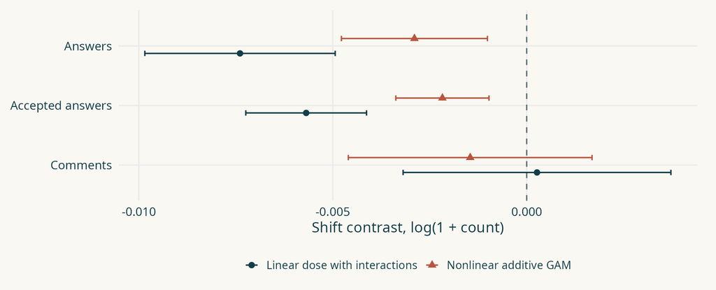

Full eligible training: 25,218 users. +5-pp supported target: 15,822 users. Linear and additive GAM; 95% pointwise intervals, 200 user bootstraps with fixed support and GAM penalties.

**Preserved broader target, including zero loss, with transformed prior covariates.** Full eligible training: 25,218 users. +5-pp supported target: 15,822 users. Linear and additive GAM; 95% pointwise intervals, 200 user bootstraps with fixed support and GAM penalties.

Answers and accepted answers have negative intervals in both models; comment intervals include zero.

## Appendix: all supported users — activity, +10 pp

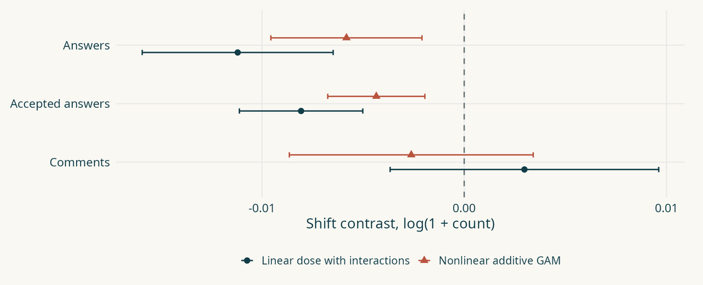

Full eligible training: 25,218 users. +10-pp supported target: 12,227 users. Linear and additive GAM; 95% pointwise intervals, 200 user bootstraps with fixed support and GAM penalties.

**Preserved broader target, including zero loss, with transformed prior covariates.** Full eligible training: 25,218 users. +10-pp supported target: 12,227 users. Linear and additive GAM; 95% pointwise intervals, 200 user bootstraps with fixed support and GAM penalties.

Answers and accepted answers have negative intervals in both models; comment intervals include zero.

## Appendix: all supported users — activity, +15 pp

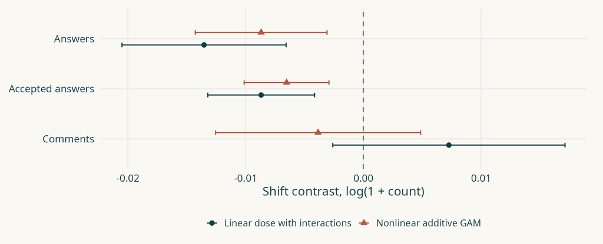

Full eligible training: 25,218 users. +15-pp supported target: 8,801 users. Linear and additive GAM; 95% pointwise intervals, 200 user bootstraps with fixed support and GAM penalties.

**Preserved broader target, including zero loss, with transformed prior covariates.** Full eligible training: 25,218 users. +15-pp supported target: 8,801 users. Linear and additive GAM; 95% pointwise intervals, 200 user bootstraps with fixed support and GAM penalties.

Answers and accepted answers have negative intervals in both models. Both comment intervals include zero.

## Appendix: all supported users — activity, +20 pp

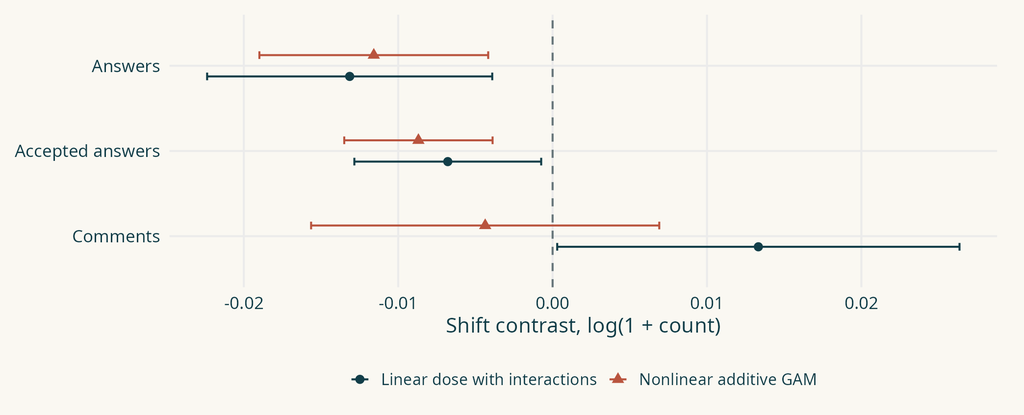

Full eligible training: 25,218 users. +20-pp supported target: 5,770 users. Linear and additive GAM; 95% pointwise intervals, 200 user bootstraps with fixed support and GAM penalties.

**Preserved broader target, including zero loss, with transformed prior covariates.** Full eligible training: 25,218 users. +20-pp supported target: 5,770 users. Linear and additive GAM; 95% pointwise intervals, 200 user bootstraps with fixed support and GAM penalties.

Answers and accepted answers have negative intervals in both models. Comments are positive only in the linear model.

## Appendix: all supported users — activity, +25 pp

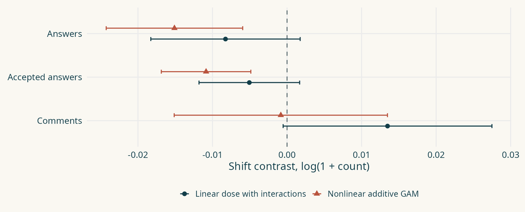

Full eligible training: 25,218 users. +25-pp supported target: 2,755 users. Linear and additive GAM; 95% pointwise intervals, 200 user bootstraps with fixed support and GAM penalties.

**Preserved broader target, including zero loss, with transformed prior covariates.** Full eligible training: 25,218 users. +25-pp supported target: 2,755 users. Linear and additive GAM; 95% pointwise intervals, 200 user bootstraps with fixed support and GAM penalties.

GAM: answers and accepted answers have negative intervals; linear intervals include zero. Both comment intervals include zero.

## Appendix: all supported users — weekly answers

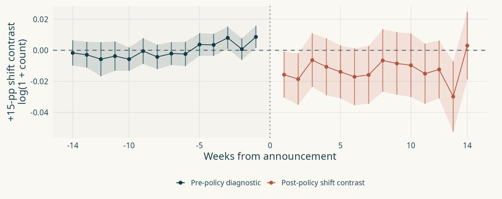

Updated weekly additive GAM: +15-pp contrast. Eligible users with this observed week and a valid pre mean; supported users enter the average.

**Preserved broader target, including zero loss, with transformed prior covariates.** Updated additive GAM; 200 user bootstraps; 95% pointwise intervals, with no joint correction across weeks/outcomes. Training and supported target users vary by week; pre-policy points are diagnostics.

Post-policy intervals are below zero in weeks +1, +2 and +13; the other weeks include zero. Pre-policy diagnostic departures also occur.

## Appendix: all supported users — weekly accepted answers

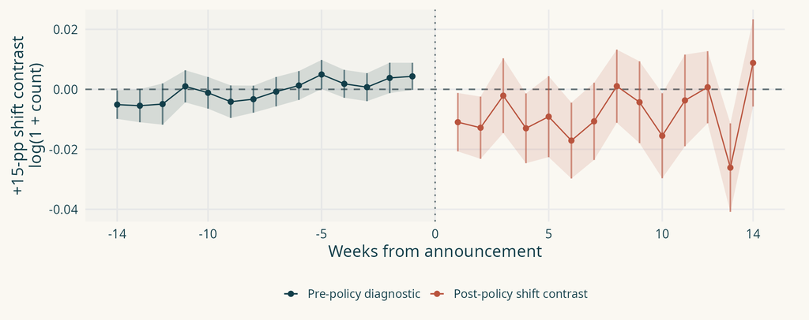

Updated weekly additive GAM: +15-pp contrast. Eligible users with this observed week and a valid pre mean; supported users enter the average.

**Preserved broader target, including zero loss, with transformed prior covariates.** Updated additive GAM; 200 user bootstraps; 95% pointwise intervals, with no joint correction across weeks/outcomes. Training and supported target users vary by week; pre-policy points are diagnostics.

Six of 14 post-policy intervals are below zero; the pattern is not uniform. Pre-policy departures and changing weekly samples limit causal interpretation.

## Appendix: all supported users — weekly comments

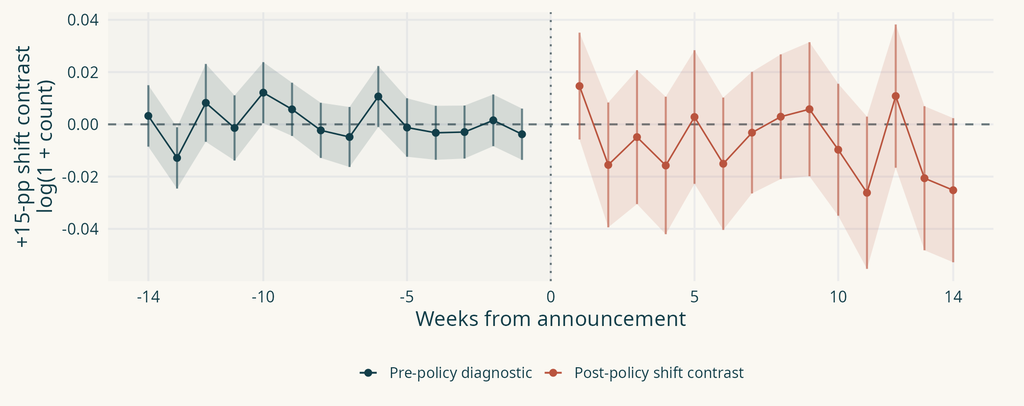

Updated weekly additive GAM: +15-pp contrast. Eligible users with this observed week and a valid pre mean; supported users enter the average.

**Preserved broader target, including zero loss, with transformed prior covariates.** Updated additive GAM; 200 user bootstraps; 95% pointwise intervals, with no joint correction across weeks/outcomes. Training and supported target users vary by week; pre-policy points are diagnostics.

All 14 post-policy intervals include zero. The weekly direction remains uncertain; individual pre-policy departures should be read with the full series.

## Appendix: all supported users — emotions, +15 pp

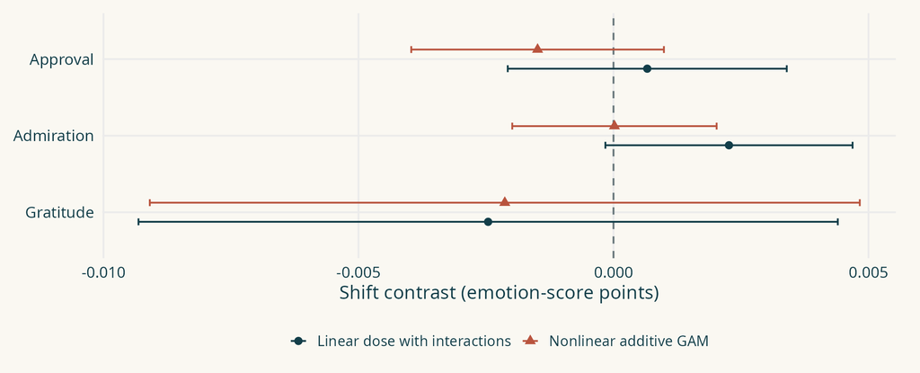

Full eligible training: 15,982 users. +15-pp supported target: 4,809 users. Linear and additive GAM; 95% pointwise intervals, 200 user bootstraps with fixed support and GAM penalties.

**Preserved broader target, including zero loss, with transformed prior covariates.** Full eligible training: 15,982 users. +15-pp supported target: 4,809 users. Linear and additive GAM; 95% pointwise intervals, 200 user bootstraps with fixed support and GAM penalties.

Approval, admiration and gratitude: all intervals include zero in both models.

## Appendix: all supported users — emotions, +5 pp

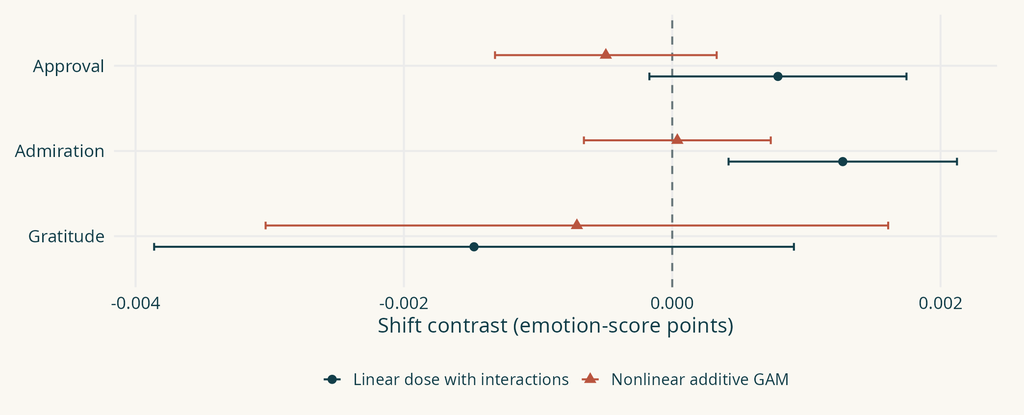

Full eligible training: 15,982 users. +5-pp supported target: 10,011 users. Linear and additive GAM; 95% pointwise intervals, 200 user bootstraps with fixed support and GAM penalties.

**Preserved broader target, including zero loss, with transformed prior covariates.** Full eligible training: 15,982 users. +5-pp supported target: 10,011 users. Linear and additive GAM; 95% pointwise intervals, 200 user bootstraps with fixed support and GAM penalties.

Admiration is positive only in the linear model; its GAM interval includes zero. Approval and gratitude include zero in both models.

## Appendix: all supported users — emotions, +10 pp

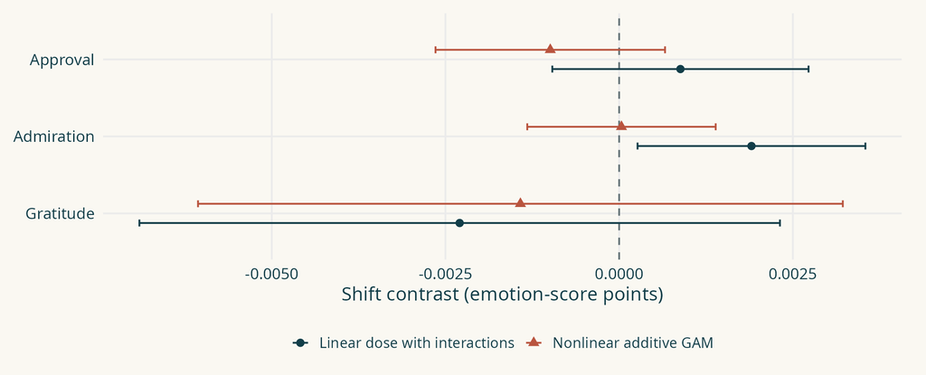

Full eligible training: 15,982 users. +10-pp supported target: 7,191 users. Linear and additive GAM; 95% pointwise intervals, 200 user bootstraps with fixed support and GAM penalties.

**Preserved broader target, including zero loss, with transformed prior covariates.** Full eligible training: 15,982 users. +10-pp supported target: 7,191 users. Linear and additive GAM; 95% pointwise intervals, 200 user bootstraps with fixed support and GAM penalties.

Admiration is positive only in the linear model; its GAM interval includes zero. Approval and gratitude include zero in both models.

## Appendix: all supported users — emotions, +20 pp

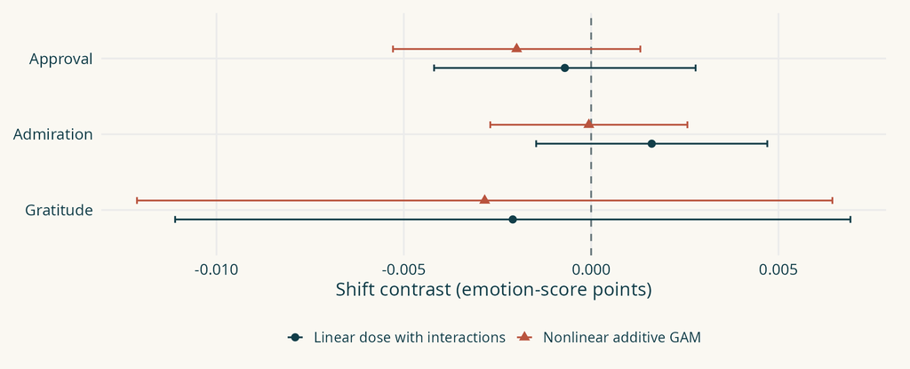

Full eligible training: 15,982 users. +20-pp supported target: 2,817 users. Linear and additive GAM; 95% pointwise intervals, 200 user bootstraps with fixed support and GAM penalties.

**Preserved broader target, including zero loss, with transformed prior covariates.** Full eligible training: 15,982 users. +20-pp supported target: 2,817 users. Linear and additive GAM; 95% pointwise intervals, 200 user bootstraps with fixed support and GAM penalties.

Approval, admiration and gratitude: all intervals include zero in both models.

## Appendix: all supported users — emotions, +25 pp

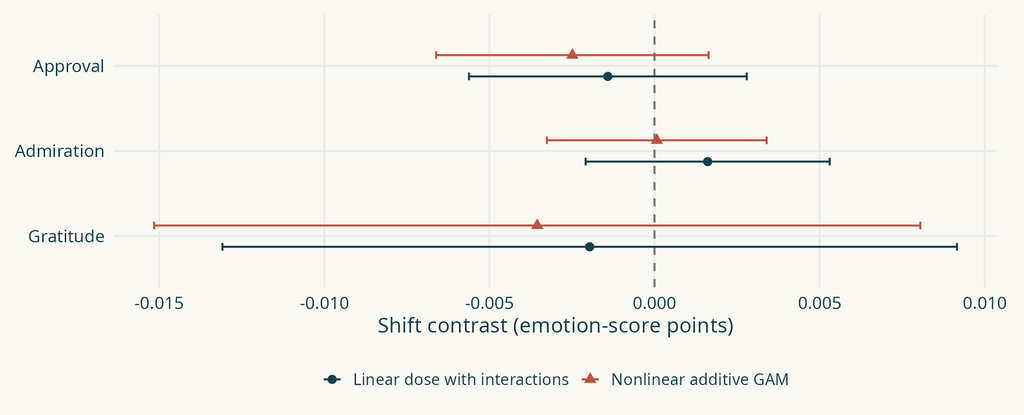

Full eligible training: 15,982 users. +25-pp supported target: 1,519 users. Linear and additive GAM; 95% pointwise intervals, 200 user bootstraps with fixed support and GAM penalties.

**Preserved broader target, including zero loss, with transformed prior covariates.** Full eligible training: 15,982 users. +25-pp supported target: 1,519 users. Linear and additive GAM; 95% pointwise intervals, 200 user bootstraps with fixed support and GAM penalties.

Approval, admiration and gratitude: all intervals include zero in both models.

## Earlier training sensitivity: all supported users

| +15-pp contrast | Earlier linear | Full-training linear | Earlier GAM | Full-training GAM |
| --- | --- | --- | --- | --- |
| Answers | −0.0151 | −0.0135 | −0.0115 | −0.0087 |
| Accepted answers | −0.0165 | −0.0087 | −0.0111 | −0.0065 |
| Comments | −0.0289 | +0.0073 | −0.0274 | −0.0038 |

**Historical broader target: same 8,801 users, including zero loss.** The earlier negative comments result does not persist. This is sensitivity to how the outcome relationship is fitted, beyond a change in precision.

Point estimates in log(1 + count). Earlier: fit within +15-pp support (8,801 users). Current: fit all eligible valid-outcome users (25,218). Both average on the same target. Full-training intervals are in this appendix; this table is not a test of differences between versions.

## Activity effects controlling total contributions

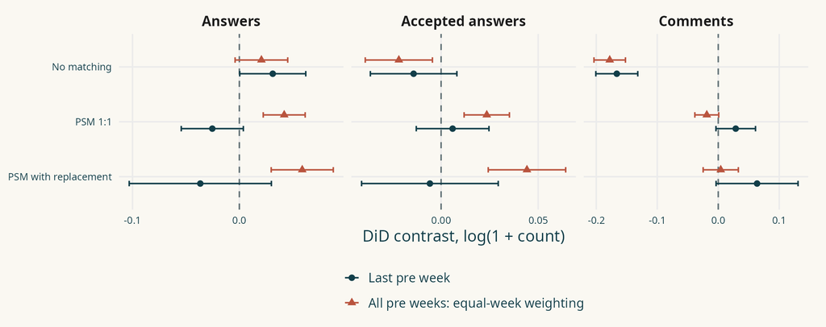

Three populations; both fitted references; 95% user-cluster multiplier intervals conditional on matching. Effects in log(1 + count).

Three populations; both fitted references; 95% user-cluster multiplier intervals conditional on matching. Effects in log(1 + count).

Appendix conditional comparison: weekly total contains the outcome itself and may respond to the policy. This is not the primary DiD specification.

## Weekly answers: total-volume adjustment

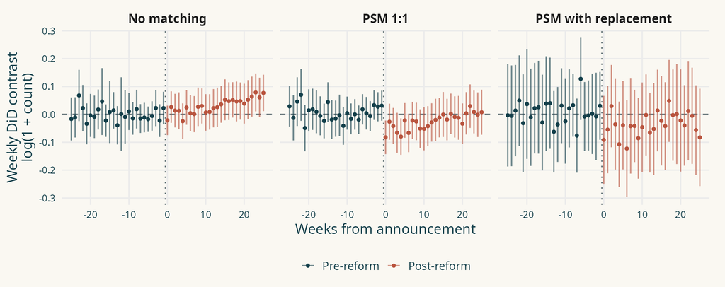

Weekly-reference event studies; identical vertical scale across populations. Simultaneous 95% bands within each model.

Weekly-reference event studies; identical vertical scale across populations. Simultaneous 95% bands within each model.

Appendix conditional comparison: weekly total contains the outcome itself and may respond to the policy. This is not the primary DiD specification.

## Weekly accepted answers: total-volume adjustment

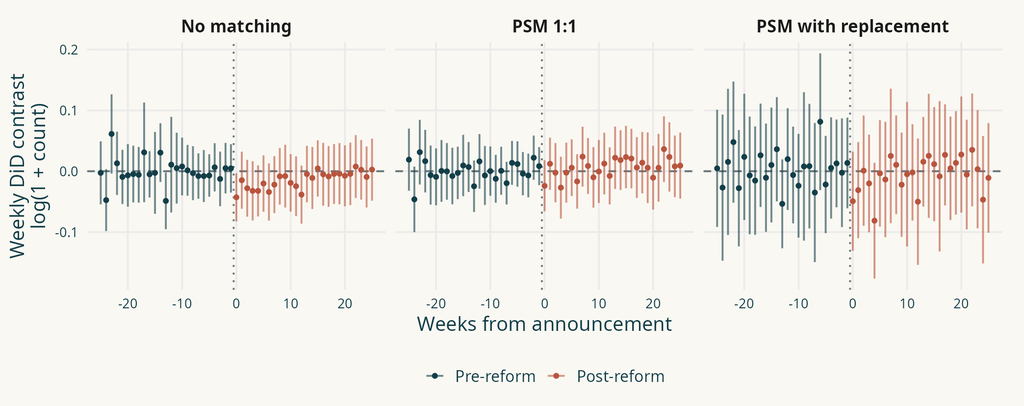

Weekly-reference event studies; identical vertical scale across populations. Simultaneous 95% bands within each model.

Weekly-reference event studies; identical vertical scale across populations. Simultaneous 95% bands within each model.

Appendix conditional comparison: weekly total contains the outcome itself and may respond to the policy. This is not the primary DiD specification.

## Weekly comments: total-volume adjustment

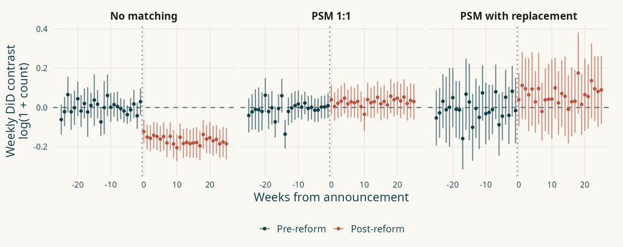

Weekly-reference event studies; identical vertical scale across populations. Simultaneous 95% bands within each model.

Weekly-reference event studies; identical vertical scale across populations. Simultaneous 95% bands within each model.

Appendix conditional comparison: weekly total contains the outcome itself and may respond to the policy. This is not the primary DiD specification.

## Activity effects controlling other-activity days

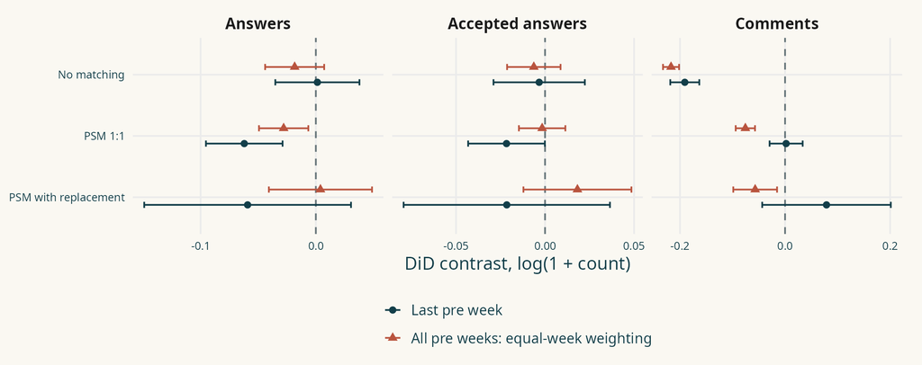

Three populations; both fitted references; 95% user-cluster multiplier intervals conditional on matching. Effects in log(1 + count).

Three populations; both fitted references; 95% user-cluster multiplier intervals conditional on matching. Effects in log(1 + count).

Appendix conditional comparison: days with other activities may respond to the policy. This is not the primary DiD specification.

## Weekly answers: other-activity days

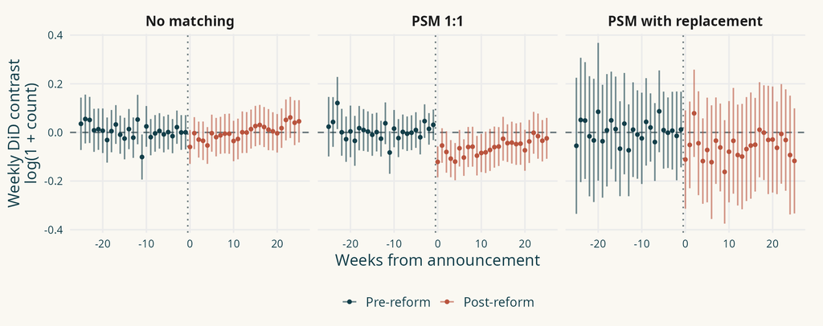

Weekly-reference event studies; identical vertical scale across populations. Simultaneous 95% bands within each model.

Weekly-reference event studies; identical vertical scale across populations. Simultaneous 95% bands within each model.

Appendix conditional comparison: days with other activities may respond to the policy. This is not the primary DiD specification.

## Weekly accepted answers: other-activity days

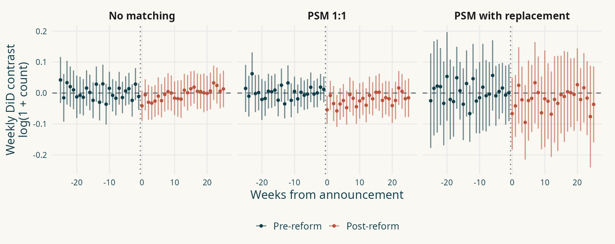

Weekly-reference event studies; identical vertical scale across populations. Simultaneous 95% bands within each model.

Weekly-reference event studies; identical vertical scale across populations. Simultaneous 95% bands within each model.

Appendix conditional comparison: days with other activities may respond to the policy. This is not the primary DiD specification.

## Weekly comments: other-activity days

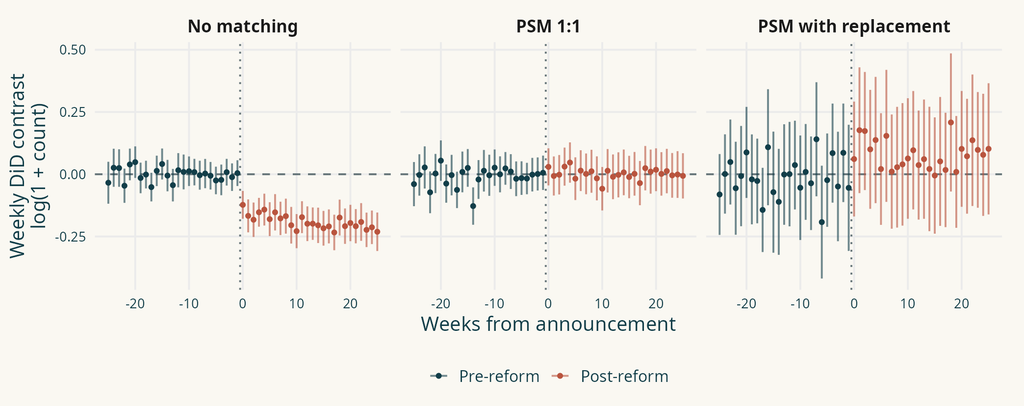

Weekly-reference event studies; identical vertical scale across populations. Simultaneous 95% bands within each model.

Weekly-reference event studies; identical vertical scale across populations. Simultaneous 95% bands within each model.

Appendix conditional comparison: days with other activities may respond to the policy. This is not the primary DiD specification.

## Earlier fit only: weekly activity at +15 pp

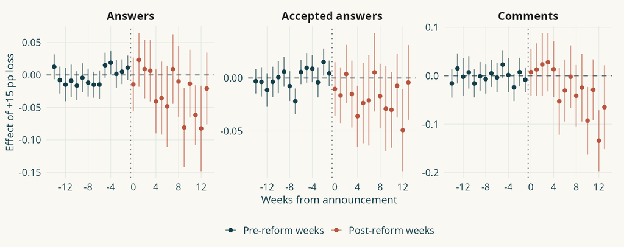

GAM fitted by week; outcome = weekly log count minus own pre mean. Supported users with a pre mean and an observed active week: 1,821–3,567 per week. Pointwise 95% intervals, 200 user bootstraps.

**Earlier specification:** model fitted within supported users; not reestimated with full training. GAM fitted by week; outcome = weekly log count minus own pre mean. Supported users with a pre mean and an observed active week: 1,821–3,567 per week. Pointwise 95% intervals, 200 user bootstraps.

Pre-period deviations occur in answers and accepted answers; comments have two negative post weeks outside their intervals. Interpret alongside the changing weekly sample.

## Earlier fit only: weekly focal emotions

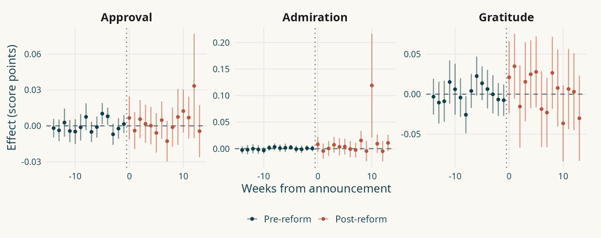

Approval, admiration and gratitude are shown in original score units; compare estimates and intervals.

## Earlier fixed-population fit: activity

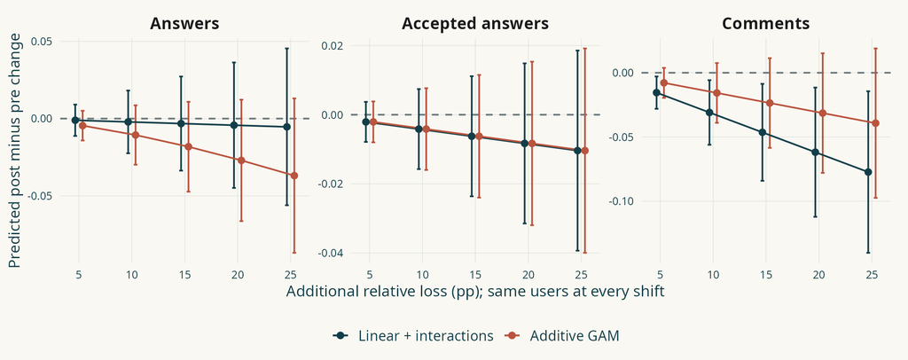

Five increments; the same 2,301 activity users at every shift. Linear and additive GAM; normal 95% intervals from 200 user bootstraps. Original observed active weeks.

**Earlier specification:** model fitted within supported users; not reestimated with full training. Five increments; the same 2,301 activity users at every shift. Linear and additive GAM; normal 95% intervals from 200 user bootstraps. Original observed active weeks.

Comments decline in the linear model at all five shifts; GAM intervals include zero. Answer and accepted-answer intervals span zero.

## Earlier fixed-population fit: focal emotions

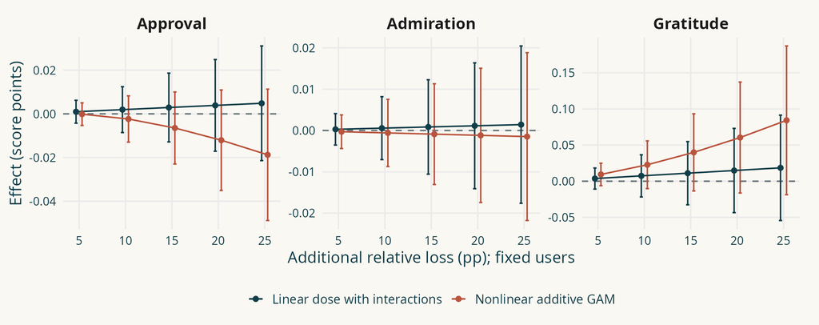

Fixed common-support text sample: 1,241 users at each increment. Linear and additive GAM; 95% pointwise intervals, 200 user bootstraps.

**Earlier specification:** model fitted within supported users; not reestimated with full training. Fixed common-support text sample: 1,241 users at each increment. Linear and additive GAM; 95% pointwise intervals, 200 user bootstraps.

Approval, admiration and gratitude are shown in original score units; compare estimates and intervals.

## Earlier fixed-population fit: emotions at +15 pp

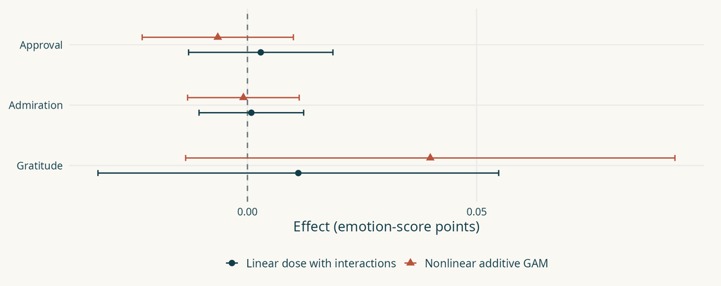

Fixed common-support text sample: 1,241 users; +15-pp relative-loss contrast. Linear and additive GAM; 95% intervals, 200 user bootstraps. No joint multiplicity correction.

**Earlier specification:** model fitted within supported users; not reestimated with full training. Fixed common-support text sample: 1,241 users; +15-pp relative-loss contrast. Linear and additive GAM; 95% intervals, 200 user bootstraps. No joint multiplicity correction.

All three intervals include zero in both dose models at +15 pp.

## CEM specifications use the same `did` model

```r
# CEM: exact matching on coarsened prior history
z[, cem_stratum := interaction(comments_band, tenure_band, reputation_band,
                               answers_band)]  # band combination
z = z[nt > 0 & nc > 0 & nt / nc <= 10]    # keep strata with both groups, at most 10 treated per control
z[, weight := fifelse(treated == 1, 1, (mc / mt) * (nt / nc))] # mc, mt: retained totals
# empirical CEM: same, with prior-answer bands cut at the pooled deciles

fit = att_gt(..., weightsname = "weight", allow_unbalanced_panel = TRUE)
# CEM and PSM: design weights; xformla omitted, so outcome-stage covariates = intercept
```

**Input.** Earlier histories grouped into bands; `nt` / `nc`: treated / comparison users in each stratum.

**Objects.** `cem_stratum`: band combination; `weight`: treated weight 1, comparison weights scaled within retained strata.

**Result.** User weights enter `att_gt`; CEM itself does not estimate the outcome effect. These are historical designs.

Code excerpt: `Earlier CEM designs used in the saved text comparisons`. Objects are prepared by the full script.

Historical transformed matches: PSM **13,593**; fixed CEM **21,200**; empirical CEM **21,304**. Current raw-unit activity PSM is reported in the main slides. The unmatched DiD uses all available outcome observations from the eligible frame.

## Activity results differ across matching designs

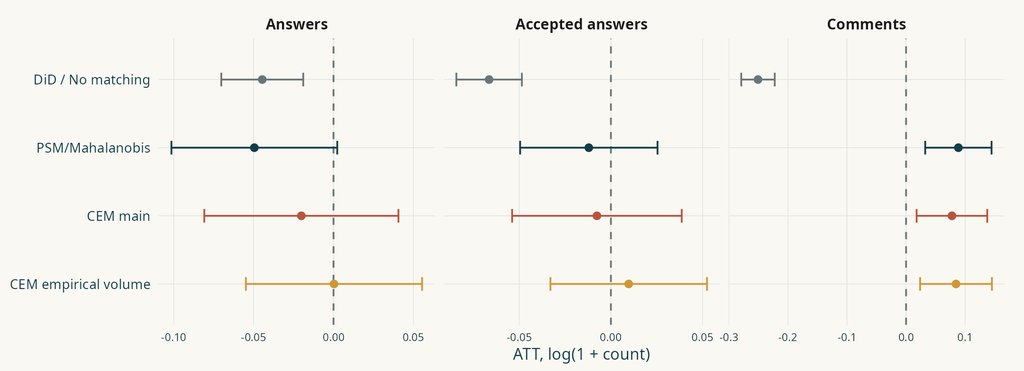

Average ATT (aggte simple) on the activity panel, ±26 weeks, observed active weeks only; no added zero weeks; reference = last pre week. Bars: 95% intervals.

Saved matching estimates use transformed predictors; raw-unit refit pending. Average ATT (aggte simple) on the activity panel, ±26 weeks, observed active weeks only; no added zero weeks; reference = last pre week. Bars: 95% intervals.

**Unmatched DiD is negative in all three outcomes; comments are positive under PSM and both CEM designs.** The designs retain different users and observed weeks.

## DiD with and without prior activity intensity

| Outcome · log(1 + count) | Without activity control | With activity intensity |
| --- | --- | --- |
| Answers | −0.045 [−0.072, −0.018] | −0.155 [−0.183, −0.127] |
| Accepted answers | −0.066 [−0.085, −0.048] | −0.134 [−0.154, −0.114] |
| Comments | −0.251 [−0.279, −0.222] | −0.366 [−0.398, −0.335] |

Same 85,605 users, observed active-week panel and outcome-regression estimator (reg). The only model difference is xformla: intercept versus one prior activity-intensity index.

The intensity adjustment increases the estimated decline in this DiD specification. This comparison holds sample and estimator fixed.

Earlier prior-intensity specification; current weekly-control results are in the main section.

## Construct one prior activity-intensity control

```r
# users = user_treatment_r.csv; d = the original observed weekly panel.
pre = d[t_week < 0, .(pre_activity = sum(c + a)), by = user_id]
volume = users[, .(user_id, pre_weeks = pmin(26, fifelse(
  !is.na(first_date_user), (1268942400 - first_date_user) / 604800, tenure)))]
# Use saved registration tenure when the first-date field is missing.
volume = merge(volume, pre, by = "user_id", all.x = TRUE)
volume[is.na(pre_activity), pre_activity := 0]
volume[, pre_rate := pre_activity / pre_weeks]
volume[, pre_log_activity := log1p(pre_rate)]
d = merge(d, volume[, .(user_id, pre_log_activity)], by = "user_id", all.x = TRUE)
```

**Input.** `users`: registration information; `d`: original observed weekly activity.

**Objects.** `pre`: earlier comments + answers; `volume`: observable pre-weeks, rate and `pre_log_activity`.

**Result.** Join one fixed prior-intensity measure to `d`. This is a historical baseline control, not a weekly-varying indicator.

Code excerpt: `Earlier prior-intensity specification; retained for reference`. Objects are prepared by the full script.

**One control: log(1 + prior comments and answers per observable week).** The denominator includes inactive time and partial weeks. The 26-week lookback is not an eligibility filter.

Earlier prior-intensity specification; current weekly-control results are in the main section.

## DiD with one activity-volume control

```r
# pre_log_activity is constructed on the previous slide, BEFORE the reform.
attgt_a = att_gt(yname = "a_log", tname = "t_week", idname = "user_id",
                 gname = "treated", data = d,
                 xformla = ~ pre_log_activity,  # ONE prior activity-intensity control
                 est_method = "reg", allow_unbalanced_panel = TRUE,
                 control_group = "nevertreated", anticipation = 0,
                 base_period = "varying")
agg_a = aggte(attgt_a, type = "simple")
agg_dyn_a = aggte(attgt_a, type = "dynamic")
# Repeat for accepted answers and comments.
# Without-control comparison: SAME data and est_method = "reg", xformla = ~ 1.
```

**Input.** `d`: observed outcomes plus each user’s fixed `pre_log_activity`.

**Objects.** `attgt_a`: adjusted group-time estimates; `agg_a`: average; `agg_dyn_a`: weekly event study.

**Result.** Historical adjusted results. The comparison removes this one covariate while retaining data and outcome-regression method.

Code excerpt: `Earlier prior-intensity DiD; retained for reference`. Objects are prepared by the full script.

**Intensity = log(1 + (pre comments + pre answers) / observable pre weeks).** Comparisons with and without this control use the same users and the same outcome-regression estimator.

Earlier prior-intensity specification; current weekly-control results are in the main section.

## Adjusted event study: outcomes differ

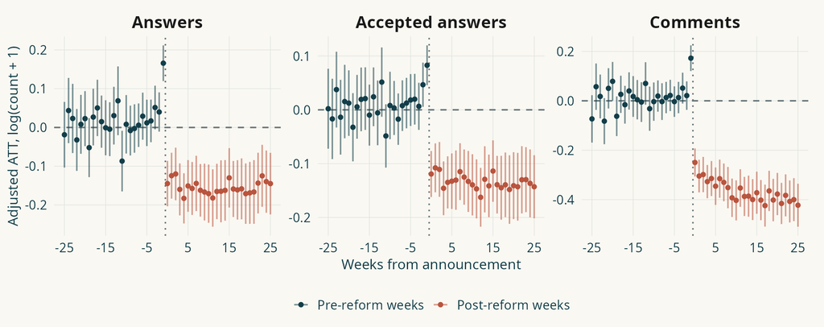

DiD adjusted for log(1 + (pre comments + pre answers) / observable pre weeks), one activity-volume control; est_method = reg. Original active-week panel, 85,605 users. Simultaneous 95% bands; varying pre-period base. Week 0 = first post week.

One control: log(1 + (pre comments + pre answers) / observable pre weeks); outcome regression. Original active-week panel, 85,605 users. Simultaneous 95% bands; week 0 = first post week.

**Adjusted average ATT: answers −0.155; accepted answers −0.134; comments −0.366.** All three intervals exclude zero; original observed active-week panel.

Earlier prior-intensity specification; current weekly-control results are in the main section.

## TWFE: three weekly activity specifications

```r
# One weekly control at a time; its effect is not interacted with post.
fit = plm(a_log ~ treated:post + days_questions_comments,
          data = pd, model = "within", effect = "twoways")
# Alternatives: omit the control, or replace it with weekly_activity_volume.
# For c_log, the days control is days_questions_answers.
# Historical reputation s is retained for accepted answers and continuous TWFE.
coeftest(fit, vcov = function(x) vcovHC(x, cluster = "group", type = "HC1"))
```

**Input.** `pd`: user-week panel; `treated:post`: binary loss contrast; at most one weekly activity control.

**Objects.** `fit`: user/week fixed-effects model. `coeftest` attaches user-clustered HC1 uncertainty to coefficients.

**Result.** Static coefficients and intervals for appendix plots; these are not `aggte` averages or weekly event-study effects.

Code excerpt: `36_weekly_active_days_models.R, appendix TWFE checks`. Objects are prepared by the full script.

Static binary and continuous treatment coefficients, with user and week effects. They answer a different estimating equation from the group-time DiD.

## Binary TWFE: three activity specifications

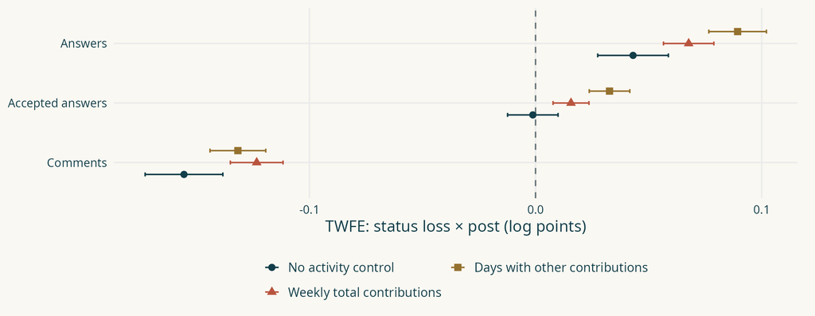

Same samples within treatment specification; 95% HC1 intervals clustered by user. Continuous models restrict relative loss to ≤100%.

Same samples within treatment specification; 95% HC1 intervals clustered by user. Continuous models restrict relative loss to ≤100%.

All three adjustments preserve a negative comments coefficient. TWFE remains a separate specification in the appendix.

## Continuous TWFE: three activity specifications

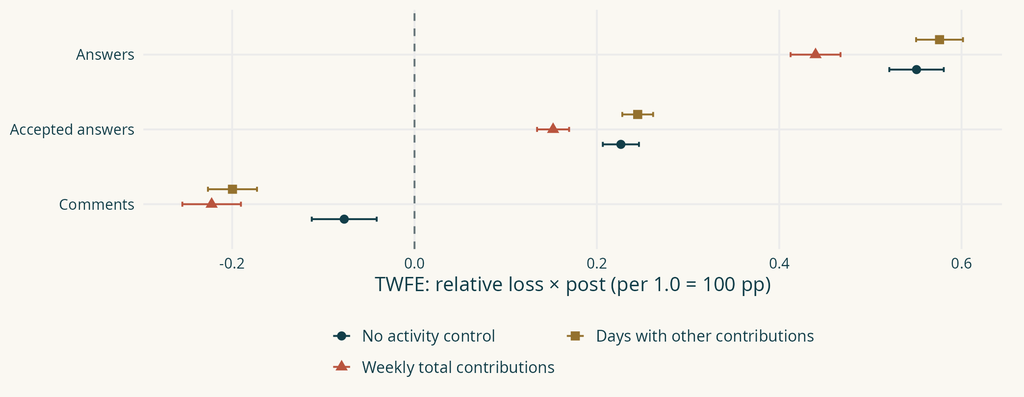

Same samples within treatment specification; 95% HC1 intervals clustered by user. Continuous models restrict relative loss to ≤100%.

Same samples within treatment specification; 95% HC1 intervals clustered by user. Continuous models restrict relative loss to ≤100%.

All three adjustments preserve a negative comments coefficient. TWFE remains a separate specification in the appendix.

## Prior volume also changes the historical dose model

| Outcome · dose × post | Without activity control | With activity intensity |
| --- | --- | --- |
| Answers | +0.551 [0.521, 0.581] | +0.307 [0.279, 0.334] |
| Accepted answers | +0.226 [0.207, 0.246] | +0.090 [0.073, 0.108] |
| Comments | −0.077 [−0.113, −0.041] | −0.378 [−0.412, −0.344] |

TWFE with user and week effects; penalty_prop × post, time-varying reputation s, losses ≤100%; 85,506 users. Adjusted models add post × log(1 + (pre comments + pre answers) / observable pre weeks). User-clustered HC1 intervals.

**With prior activity intensity, historical TWFE dose coefficients are +0.307 for answers, +0.090 for accepted answers and −0.378 for comments.** Supported dose-shift estimates appear in their own sections.

Earlier prior-intensity specification; current weekly-control results are in the main section.

## Unmatched text DiD: all 28 emotions · 2/2

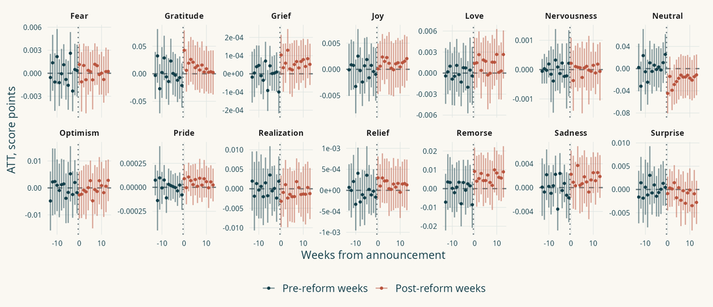

Weekly DiD without matching; emotion scores 0–1. Simultaneous 95% bands within label. All labels retained.

Weekly DiD without matching; emotion scores 0–1. Simultaneous 95% bands within label. All labels retained.

Inspect pre-reform deviations and persistence; isolated weeks across many labels require caution.

## PSM event study: all 28 emotions · 2/2

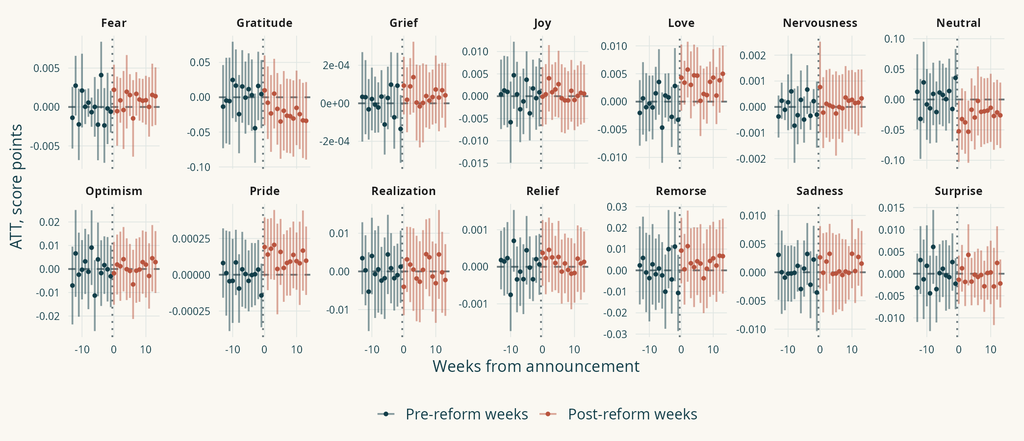

did dynamic ATT, PSM/Mahalanobis on the eligible analysis sample (13,593 pairs). Bars: simultaneous 95% bands. Post points compare with the last pre week; week 0 = first week after announcement. Emotion-score points (0–1). Labels Fear–Surprise.

Saved matching estimates use transformed predictors; raw-unit refit pending. did dynamic ATT, PSM/Mahalanobis on the eligible analysis sample (13,593 pairs). Bars: simultaneous 95% bands. Post points compare with the last pre week; week 0 = first week after announcement. Emotion-score points (0–1). Labels Fear–Surprise.

## Text across designs and references · 2/4

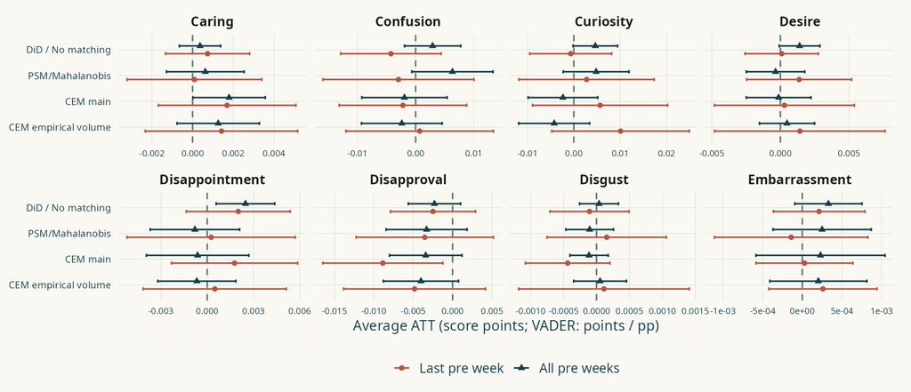

Average ATT on user-week means, four comparison designs (unmatched DiD, PSM and two CEM), eligible analysis sample. Circles: reference = last pre week; triangles: all pre weeks. Emotions in score points (0–1); VADER valence in points, shares in pp. Bars: 95% intervals.

Saved matching estimates use transformed predictors; raw-unit refit pending. Average ATT on user-week means, four comparison designs (unmatched DiD, PSM and two CEM), eligible analysis sample. Circles: reference = last pre week; triangles: all pre weeks. Emotions in score points (0–1); VADER valence in points, shares in pp. Bars: 95% intervals.

Gratitude falls with the broad reference in all four designs. Its last-week intervals include zero; the finding depends on the pre-period summary.

## Text across designs and references · 3/4

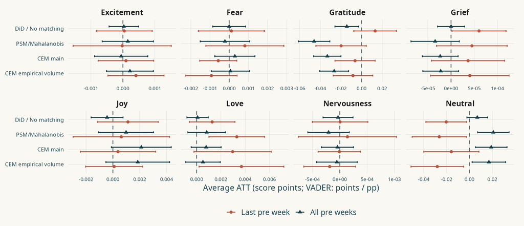

Average ATT on user-week means, four comparison designs (unmatched DiD, PSM and two CEM), eligible analysis sample. Circles: reference = last pre week; triangles: all pre weeks. Emotions in score points (0–1); VADER valence in points, shares in pp. Bars: 95% intervals.

Saved matching estimates use transformed predictors; raw-unit refit pending. Average ATT on user-week means, four comparison designs (unmatched DiD, PSM and two CEM), eligible analysis sample. Circles: reference = last pre week; triangles: all pre weeks. Emotions in score points (0–1); VADER valence in points, shares in pp. Bars: 95% intervals.

Neutral reverses sign across references in PSM and empirical CEM. Other findings are isolated across labels and designs.

## Text across designs and references · 4/4

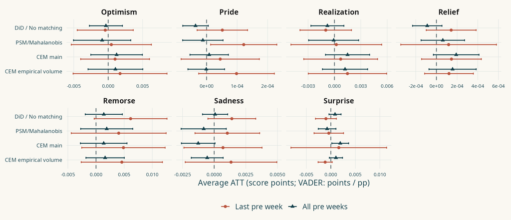

Average ATT on user-week means, four comparison designs (unmatched DiD, PSM and two CEM), eligible analysis sample. Circles: reference = last pre week; triangles: all pre weeks. Emotions in score points (0–1); VADER valence in points, shares in pp. Bars: 95% intervals.

Saved matching estimates use transformed predictors; raw-unit refit pending. Average ATT on user-week means, four comparison designs (unmatched DiD, PSM and two CEM), eligible analysis sample. Circles: reference = last pre week; triangles: all pre weeks. Emotions in score points (0–1); VADER valence in points, shares in pp. Bars: 95% intervals.

All labels remain visible. Treat isolated intervals cautiously: there is no joint correction across outcomes, designs and references.

## Own-support +15 pp · Text outcomes · 2/4

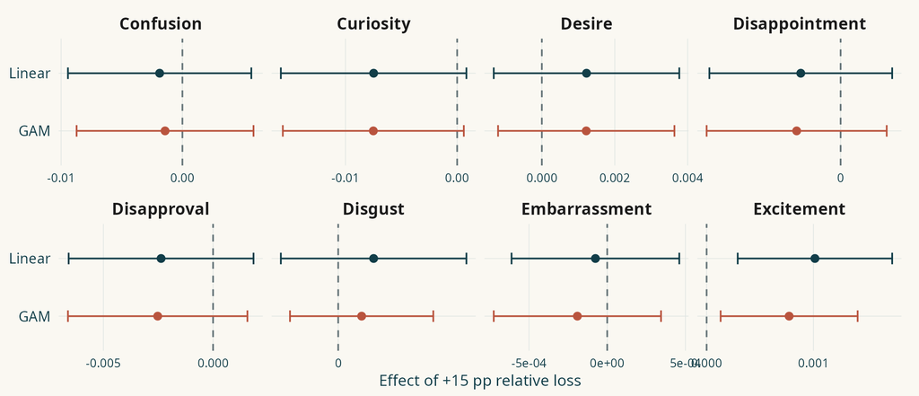

Own-support text sample: 4,809 users with pre/post comments. Linear and additive GAM; score points for emotions, percentage points for positive share. Normal 95% intervals, 200 user bootstraps.

**Earlier specification:** model fitted within supported users; not reestimated with full training. Own-support text sample: 4,809 users with pre/post comments. Linear and additive GAM; score points for emotions, percentage points for positive share. Normal 95% intervals, 200 user bootstraps.

Excitement increases in both models; other intervals on this page include zero. No joint multiplicity correction.

## Own-support +15 pp · Text outcomes · 3/4

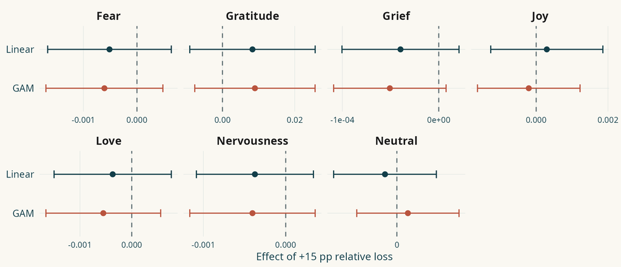

Own-support text sample: 4,809 users with pre/post comments. Linear and additive GAM; score points for emotions, percentage points for positive share. Normal 95% intervals, 200 user bootstraps.

**Earlier specification:** model fitted within supported users; not reestimated with full training. Own-support text sample: 4,809 users with pre/post comments. Linear and additive GAM; score points for emotions, percentage points for positive share. Normal 95% intervals, 200 user bootstraps.

Gratitude and neutral intervals include zero in both models. Gratitude: +0.0083 linear / +0.0090 GAM.

## Own-support +15 pp · Text outcomes · 4/4

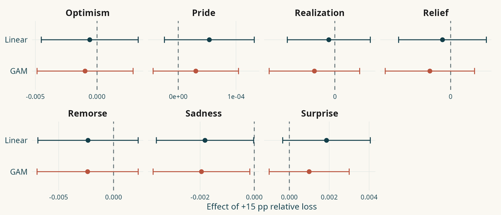

Own-support text sample: 4,809 users with pre/post comments. Linear and additive GAM; score points for emotions, percentage points for positive share. Normal 95% intervals, 200 user bootstraps.

**Earlier specification:** model fitted within supported users; not reestimated with full training. Own-support text sample: 4,809 users with pre/post comments. Linear and additive GAM; score points for emotions, percentage points for positive share. Normal 95% intervals, 200 user bootstraps.

Sadness decreases in both models; other intervals on this page include zero. No joint multiplicity correction.

## Own-support +15 pp · Weekly emotions · 2/2

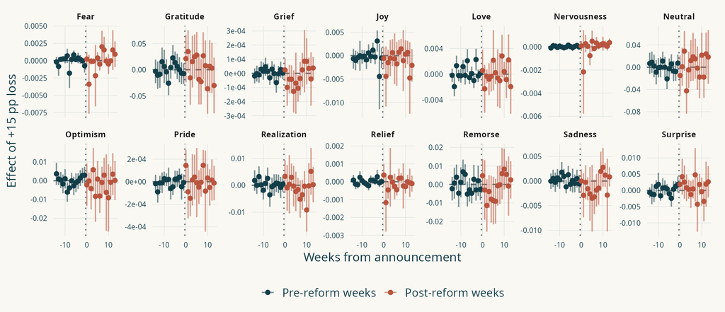

Weekly GAM on supported users with a pre mean and comments in that week: 887–1,760 users per week. All 28 labels shown over two slides. Pointwise 95% intervals, 200 user bootstraps.

**Earlier specification:** model fitted within supported users; not reestimated with full training. Weekly GAM on supported users with a pre mean and comments in that week: 887–1,760 users per week. All 28 labels shown over two slides. Pointwise 95% intervals, 200 user bootstraps.

Several labels also have pre-period deviations. Gratitude has one pre-period interval excluding zero and no post-period interval excluding zero.

## All 28 emotion scores, before and after

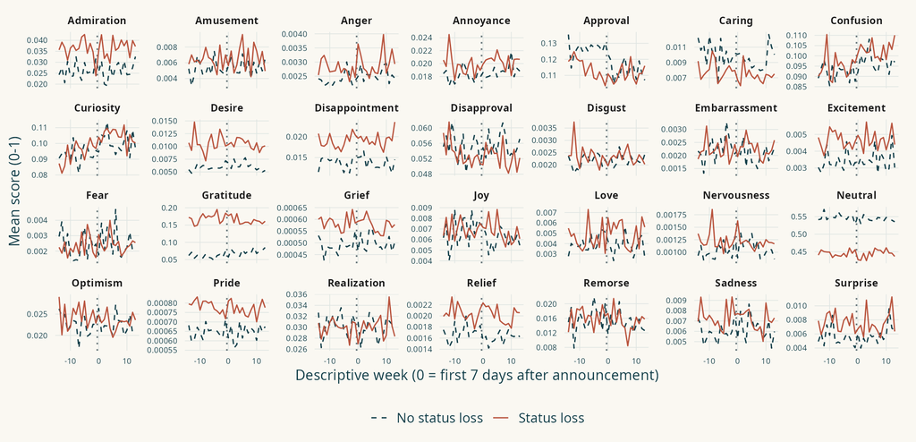

Weekly mean of each GoEmotions score (0–1) among observed PSM-matched user-weeks. Dashed petrol: no status loss; solid terracotta: status loss. Panel scales differ. Larger versions in the appendix.

Previous transformed matching; raw-unit refit pending. Weekly mean of each GoEmotions score (0–1) among observed PSM-matched user-weeks. Dashed petrol: no status loss; solid terracotta: status loss. Panel scales differ. Larger versions in the appendix.

**Descriptive levels can differ after matching.** All 28 raw scores are shown; their levels and changing participant mix are not treatment effects.

## Unmatched text DiD: all 28 emotions · 1/2

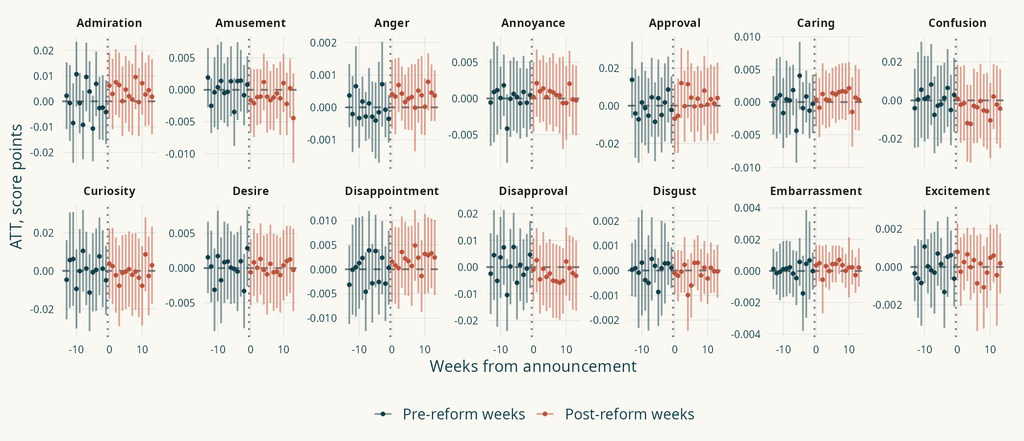

Weekly DiD without matching; emotion scores 0–1. Simultaneous 95% bands within label. All labels retained.

Weekly DiD without matching; emotion scores 0–1. Simultaneous 95% bands within label. All labels retained.

Inspect pre-reform deviations and persistence; isolated weeks across many labels require caution.

## Unmatched DiD: average effects on all 28 emotions

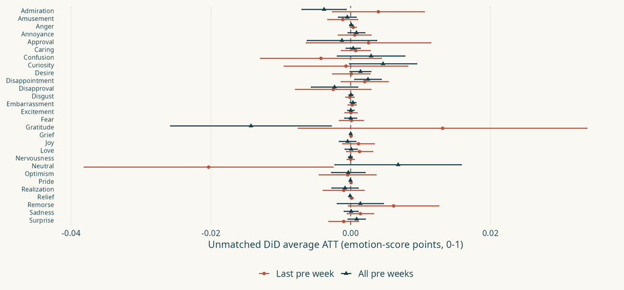

Unmatched average DiD; 40,669 users. Last pre week versus all pre weeks; 95% intervals, no joint multiplicity correction.

Unmatched average DiD; 40,669 users. Last pre week versus all pre weeks; 95% intervals, no joint multiplicity correction.

Gratitude falls with the broad reference (−0.0143), but not precisely with the last-week reference.

## PSM event study: all 28 emotions · 1/2

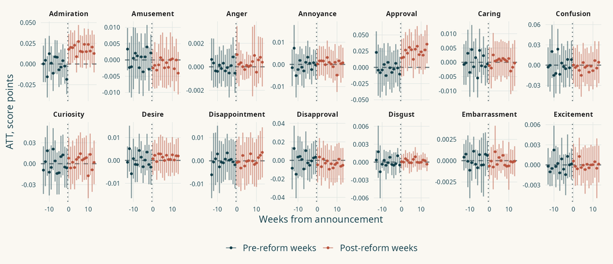

did dynamic ATT, PSM/Mahalanobis on the eligible analysis sample (13,593 pairs). Bars: simultaneous 95% bands. Post points compare with the last pre week; week 0 = first week after announcement. Emotion-score points (0–1). Labels Admiration–Excitement.

Previous transformed matching; raw-unit refit pending. did dynamic ATT, PSM/Mahalanobis on the eligible analysis sample (13,593 pairs). Bars: simultaneous 95% bands. Post points compare with the last pre week; week 0 = first week after announcement. Emotion-score points (0–1). Labels Admiration–Excitement.

Admiration and approval have several positive post weeks; admiration also has one pre-period deviation. Bands are simultaneous within label, not across labels.

## PSM average effect: all 28 emotions

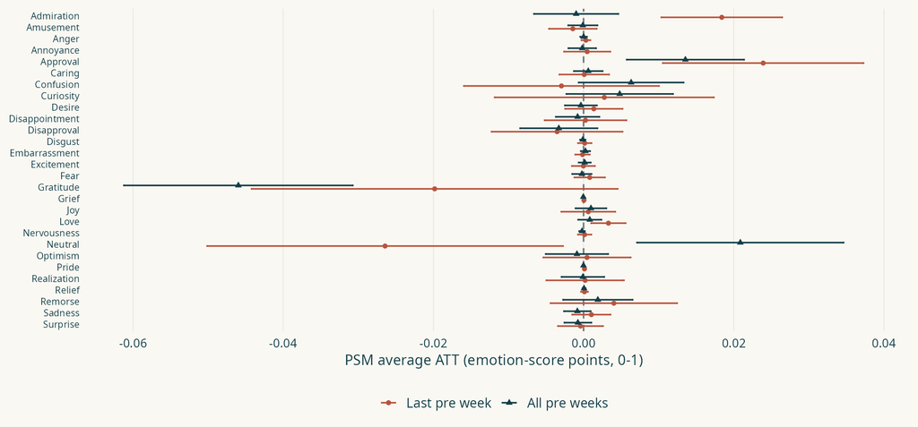

PSM/Mahalanobis average ATT on user-week mean scores (0–1), eligible analysis sample. Circles: reference = last pre week; triangles: all pre weeks. Bars: 95% intervals, no multiplicity correction.

Previous transformed matching; raw-unit refit pending. PSM/Mahalanobis average ATT on user-week mean scores (0–1), eligible analysis sample. Circles: reference = last pre week; triangles: all pre weeks. Bars: 95% intervals, no multiplicity correction.

**Approval increases with both PSM references (+0.0239 / +0.0136).** Gratitude falls with all pre weeks (−0.0460); neutral changes sign across references. Unadjusted intervals.

## Text across designs and references · 1/4

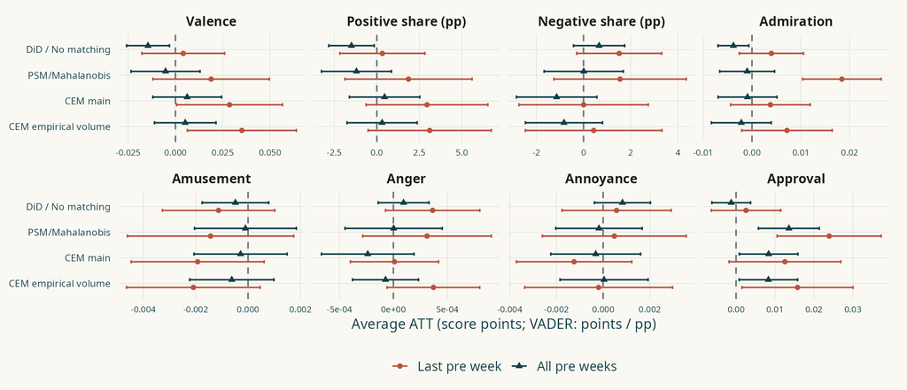

Average ATT on user-week means, four comparison designs (unmatched DiD, PSM and two CEM), eligible analysis sample. Circles: reference = last pre week; triangles: all pre weeks. Emotions in score points (0–1); VADER valence in points, shares in pp. Bars: 95% intervals.

Previous transformed matching; raw-unit refit pending. Average ATT on user-week means, four comparison designs (unmatched DiD, PSM and two CEM), eligible analysis sample. Circles: reference = last pre week; triangles: all pre weeks. Emotions in score points (0–1); VADER valence in points, shares in pp. Bars: 95% intervals.

VADER results differ by reference and design. Approval increases under PSM and empirical CEM with both references; comparisons use different selected populations.

## Earlier fixed-population fit: all text outcomes

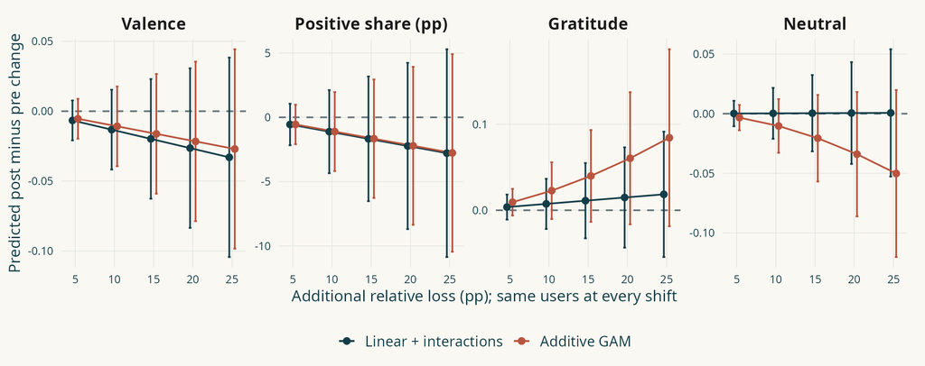

Five increments; the same 1,241 text users with pre/post comments at every shift. Valence, positive share, gratitude and neutral shown. Normal 95% intervals, 200 user bootstraps.

**Earlier specification:** model fitted within supported users; not reestimated with full training. Five increments; the same 1,241 text users with pre/post comments at every shift. Valence, positive share, gratitude and neutral shown. Normal 95% intervals, 200 user bootstraps.

All intervals shown here include zero. The next slide retains all 28 emotions at the focal +15-pp shift.

## Common support · All 28 emotions at +15 pp

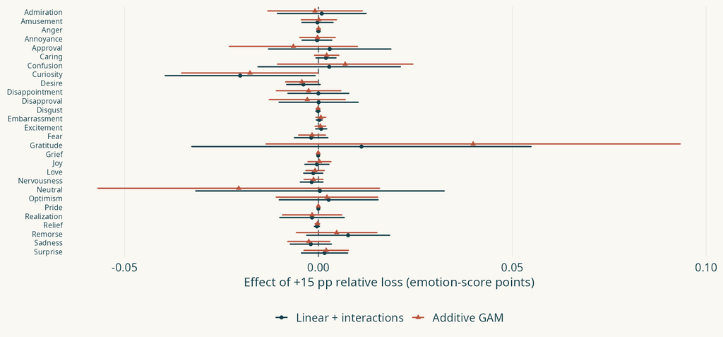

Fixed common-support text sample: 1,241 users; +15-pp relative-loss contrast. Linear and additive GAM; 95% intervals, 200 user bootstraps. No joint multiplicity correction.

**Earlier specification:** model fitted within supported users; not reestimated with full training. Fixed common-support text sample: 1,241 users; +15-pp relative-loss contrast. Linear and additive GAM; 95% intervals, 200 user bootstraps. No joint multiplicity correction.

Curiosity excludes zero in both models; desire only in GAM. These comparisons cover all 28 labels and remain model- and population-specific.